# Unidad 4

Modelamiento estadístico

Iris Ashimine

# Relaciones no lineales

Las funciones de regresión no lineales son aquellas en las que la relación entre la variable dependiente $y$ y las variables independientes $x_1,x_2,..x_k$ no es una combinación lineal, es decir, el efecto de un cambio en la variable $x_1$ no es una constante, sino que depende de otra variable.

La relación puede involucrar **polinomios, logaritmos e interacciones**. Estas regresiones se utilizan cuando se sabe que el comportamiento de la variable dependiente sigue una forma **no lineal** en lugar de una línea recta.

## Logarítmica

Las regresiones con logarítmos tienen dos funciones: - transformar variables en modelos de regresión cuando su relación no es lineal
$$y_i=e^{\beta_0+\beta_1x_{1i}+u_i}\\
log(y_i)=log(e^{\beta_0+\beta_1x_{1i}+u_i})\\
log(y_i)=\beta_0+\beta_1x_{1i}+u_i$$
- Ajustar los datos cuando tienen **distribuciones sesgadas**

### Transformar datos a logaritmos

Cuando las variables tiene distribuciones con colas largas o asimétricas, se los transforma en logaritmos, debido a que estos **comprimen los valores grandes y acentúan los pequeños**, lo que ayuda a normalizar la distribución de los datos.

- Las variables económicas, como ingresos, precios o tamaños de empresas, suelen tener distribuciones sesgadas a la derecah (colas largas). Aplicar una transformación logarítmica hace que su distribución se aproxime a una **distribución normal**.
- La transformación logarítmica también ayuda a **estabilizar la varianza** por tanto, *puede* contribuir a reducir la heterocedasticidad.
- Los coeficientes de regresiones logarítmicas también facilitan la interpretación porque se pueden leer como **elasticidades** o **cambios porcentuales**.

#### Ejemplos reales

1. **Los ingresos** suelen tener una distribución muy sesgada, ya que la mayoría de las personas ganan un salario relativamente bajo, mientras un pequeño número de personas gana salarios extremadamente altos.

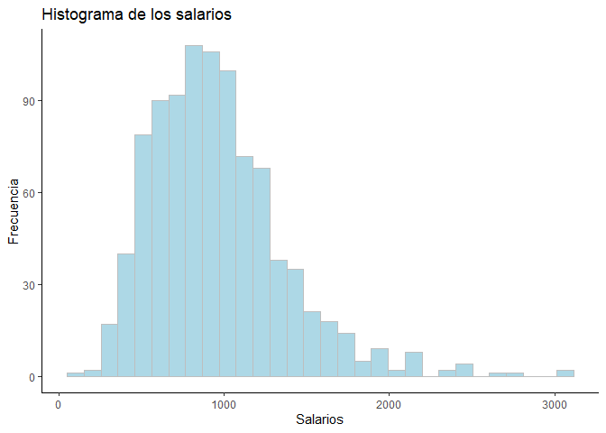

```r
ggplot(data = wage2, aes(x = wage)) +
  geom_histogram(bins=30, color = "gray", fill = "lightblue") +
  theme_classic() +
  labs(title = "Histograma de los salarios", x = "Salarios", y = "Frecuencia")
```

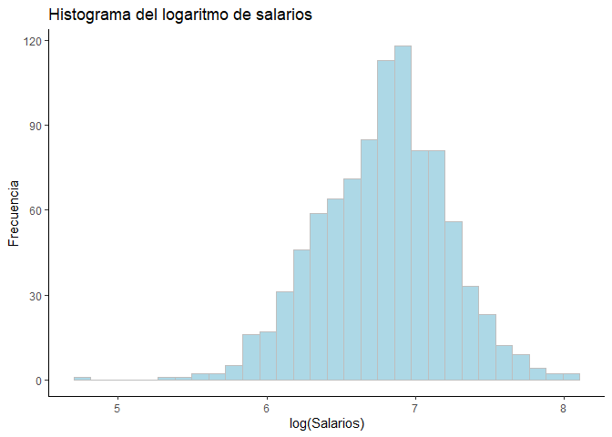

```r
ggplot(data = wage2, aes(x = lwage)) +
  geom_histogram(bins=30, color = "gray", fill = "lightblue") +
  theme_classic() +
  labs(title = "Histograma del logaritmo de salarios", x = "log(Salarios)", y = "Frecuencia")
```

2. **Los precios de viviendas** también siguen una distribución sesgada a la derecha, ya que son muy pocas las casas de “lujo” que tienen precios muy por encima de la media.

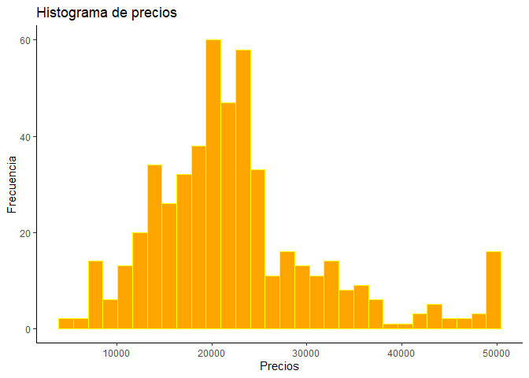

```r
data("hprice2")
ggplot(data = hprice2, aes(x =price)) +
  geom_histogram(bins=30, color = "yellow", fill = "orange") +
  theme_classic() +
  labs(title = "Histograma de precios", x = "Precios", y = "Frecuencia")
```

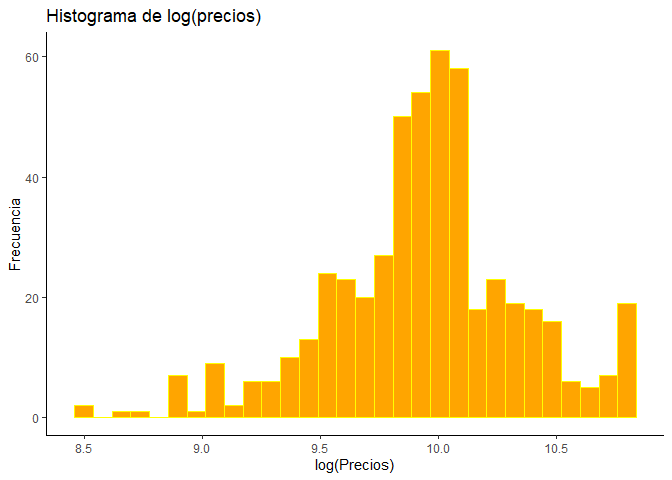

```r
ggplot(data = hprice2, aes(x =lprice)) +
  geom_histogram(bins=30, color = "yellow", fill = "orange") +
  theme_classic() +
  labs(title = "Histograma de log(precios)", x = "log(Precios)", y = "Frecuencia")
```

3. **El tamaño de las empresas** si se quieren comparar o se tiene en una misma muestra empresas grandes y empresas pequeñas, por la diferencia del tamaño de estas, aplicar una transformación logarítmica ayuda a comparar sus variables en una escala razonable.

### Log-nivel

En este caso, la **variable dependiente** está en logaritmo, mientras las **variables independientes** matienen su forma original (nivel).
$$log(y_i)=\beta_0+\beta_1x_{1i}+u_i$$
**Interpretación**: - Los coeficientes $\beta_i$ representan cómo un *cambio unitario* en $x$ provoca un *cambio porcentual* en $y$ - Si $\beta_1=0.03$, quiere decir que un aumento de **1 unidad de** $x_1$, llevará a un aumento de $3\%$ en $y$.

### Log-Log

En este tipo de regresión, tanto la **variable dependiente** como las **variables independientes** son transformadas por logaritmos.

$$log(y_i)=\beta_0+\beta_1log(x_{1i})+\beta_2 log(x_{2i})+ u_i$$
**Interpretación**

Los coeficientes $\beta_i$ en una regresión *log-log* representan **elasticidades**. Es decir, cómo cambia la variable dependiente $y$ en **porcentaje** por cada **1%** de cambio en $x_i$. - Si $\beta_1=0.5$, un aumento del $1\%$ en $x_1$ llevará a un aumento de $0.5\%$ en $y$.

**Derivación matemática**

Derivamos con respecto a $log(x_1)$
$$\frac{\Delta log(y)}{\Delta log(x)}=\beta_1$$

### Nivel-Log

En este caso, la **variable dependiente** se mantiene en su forma original (nivel), pero las **variables independientes** se transforman utilizando logaritmos.

$$y_i=\beta_0+\beta_1log(x_{i1})+u_i$$
**Interpretación**:

- Los coeficientes $\beta_i$ representan cómo un **cambio porcentual** en $x$ afecta el **nivel** de la variable dependiente $y$.
- Si $\beta_1=2$, un aumento del **1%** en $x_1$ provocaría un aumento de **2 unidades** en $y$.

### Tabla de resumen

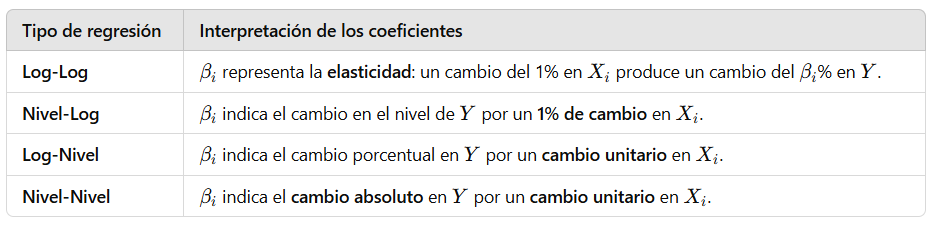

## Polinomios

Las **regresiones con polinomios** son un tipo de regresión **no lineal** que permite modelar relaciones más *flexibles*, es decir, permite un mejor ajuste cuando los datos presentan **curvaturas** o **patrones no lineales**.

$$y_i=\beta_0+\beta_1x_{1i}+\beta_2x_{i2}+\beta_3x_{1i}^2+u_i$$
Este tipo de regresiones se usa cuando: - conocemos la posibilidad de que la relación tenga una curvatura, por ejemplo, cuando el efecto de $x$ en $y$ cambia a medida que $x$ crece.

Sin embargo, utilizar polinomios sin un motivo claro (sólo para ajustar mejor los datos), tiene consecuencias:

- **Interpretación**: Cuando utilizamos polinomios de orden superior al cuadrado, es difícil dar una interpretación “económica” al coeficiente.
- **Inestabilidad de los coeficientes**: Los coeficientes se vuelen altamente sensibles a pequeños cambios o a la especificación del modelo.
- **Sobre ajuste**: u *overfitting*, es cuando se utiliza polinomios de orden superior, sin embargo, el modelo se ajusta al **ruido** de los datos y no al patrón en el que estamos interesados, esto lleva a que el modelo tenga bajo **poder predictivo** en otros datos.

### Interpretación de una regresión polinómica

La interpretación de los coeficientes de una regresión polinómica depende del grado del polinomio:

$$y_i=\beta_0+\beta_1x_{1i}+\beta_2x_{i2}+\beta_3x_{1i}^2+u_i$$
$\beta_1$ es el coeficiente *lineal* de $x_1$, $\beta_2$ es el coeficiente *cuadrático* de $x_2$.

**Derivación**
$$\frac{\delta (y|x_1)}{\delta x_1}=\beta_1+2\beta_3$$

- El signo de $\beta_2$ (el término cuadrático) indica la curvatura de la parábola:
  - Si $\beta_2$ es positivo, significa que es **convexa** (forma de U)
  - Si $\beta_2$ es negativa, significa que es **cóncava** (forma de U invertida).
- Dado que el efecto de $x_1$ en $y$ **no es constante**, es decir, **depende del valor de** $x_1$ que se esté considerando, se interpreta el *efecto marginal* o la pendiente en un valor específico de $x_1$.
- Es posible calcular el *vértice* o el punto de inflexión, es decir, el valor de $x_1$ a partir del cual, la relación con $y$ cambia de positivo a negativo o viceversa:

  $$x_v=-\frac{\beta_1}{2\beta_3}$$

### Ejemplo

Supongamos que tenemos el modelo del precio de las casas, donde estamos interesados en el *efecto* de la concentración de *óxido nitroso* y el *número de habitaciones* sobre el precio de estas:

$$lprice=\beta_0+\beta_1 lnox+\beta_2 rooms+\beta_3 rooms^2+\beta_4
dist+\beta_5stratio+\beta_6 crime+u$$

```r
library(fixest)
mco_hprice2<-feols(lprice ~ lnox + rooms + I(rooms^2)+ dist + stratio + crime, data = hprice2, vcov = "hc1")
summary(mco_hprice2)
```

```
## OLS estimation, Dep. Var.: lprice
## Observations: 506
## Standard-errors: Heteroskedasticity-robust
##              Estimate Std. Error  t value   Pr(>|t|)
## (Intercept) 13.698519   0.779575 17.57179  < 2.2e-16 ***
## lnox        -0.781222   0.089339 -8.74447  < 2.2e-16 ***
## rooms       -0.731679   0.237408 -3.08194 2.1702e-03 **
## I(rooms^2)   0.075816   0.018046  4.20117 3.1459e-05 ***
## dist        -0.035355   0.007537 -4.69110 3.5136e-06 ***
## stratio     -0.036889   0.004742 -7.77979 4.2057e-14 ***
## crime       -0.014673   0.002399 -6.11651 1.9334e-09 ***
## ---
## Signif. codes:  0 '***' 0.001 '**' 0.01 '*' 0.05 '.' 0.1 ' ' 1
## RMSE: 0.230802   Adj. R2: 0.67749
```

- Para interpretar el efecto de $lnox$ sobre $lprice$ primero tenemos que reconocer que se trata de un modelo *log-log*, por tanto, se debe interpretar $\beta_1$ como una **elasticidad**.
- **Interpretación** $\beta_1$: Un incremento en **1%** en la concentración de óxido nitroso está asociado a una disminución de **0.78%** en los precios en las casas.

Ahora queremos saber el efecto de $rooms$ sobre el precio de las casas, para la media de $rooms$

*El efecto de una casa adicional esta dado por*:

$$-0.731679+2\times0.075816\times rooms$$

```r
mean(hprice2$rooms)
```

```
## [1] 6.284051
```

El signo de $\beta_3>0$, el coeficiente de $rooms^2$, indica que la relación es **convexa** es decir, hasta un cierto número de habitaciones, el efecto del número de habitaciones es decreciente, y luego de este punto, el efecto se vuelve creciente.

# Variables binarias

En algunos casos, tenemos variables independientes $x$ no numéricas, en específico binarias. Estas variables son las que solamente toman dos valores, generalmente 0 o 1, y representan la **presencia o ausencia** de un atributo o característica. Un ejemplo común es la variable que indica si una persona tiene o no empleo: empleado=1, desempleado=0.

Las **variables binarias** se utilizan cuando se tiene una variable **cualitativa** o **categórica** que puede describirse en términos de dos grupos *mutuamente excluyentes* (ej, género). Son útiles en situaciónes donde se quiere evaluar el *efecto de una condición específica* en una variable dependiente.

## Estimación con variables binarias o dummies

Cuando se incluyen las variables binarias en un modelo de regresión, el proceso depende de la naturaleza de la *variable dependiente* si esta es continua, mientras que alguna de las variables independientes es binaria, se utiliza el modelo de **regresión lineal**, en caso contrario, (la variable *dependiente* es binaria) se utilizan modelos de **regresión logística**. En este segmento solamente abordaremos el primer caso.

**Regresión lineal con variable independiente binaria**

$$y_i=\beta_0+\beta_1x_{1i}+u_i$$
En esta ecuación, $x_{1i}$ es una variable binaria.

## Interpretación

El coeficiente $\beta_1$ indica el cambio esperado en la variable dependiente $y$ en presencia del atributo, es decir, cuando $x$ cambia de $0$ a $1$.

- Por ejemplo,si se está modelando el *salario* en función del **género**, donde $género=1$ para mujeres y $género=0$ para hombres), el coeficiente $\beta_1$ nos diría **la diferencia en salario** entre hombres y mujeres.

Retomemos el ejemplo de la primera clase:

$$\begin{align*}
E[salario|género]&=\beta_0+\beta_1género\\
E[salario|género=0]&=\beta_0\; \text{(salario de hombres)}\\
E[salario|género=1]&=\beta_0+\beta_1\; \text{(salario mujeres)}\\
E[salario|género=1]-E[salario|género=0]&=\beta_1\; \text{(diferencia
salarial)}
\end{align*}$$

# Interacciones

Los modelos de regresión con **interacciones** se utilizan cuando sabemos que las variables no actúan de forma independiente, sino que el impacto de una variable sobre la variable dependiente se ve modificado por la presencia o el valor de otra.

Los modelos con interacciones permiten modelar estas relaciones **no aditivas** entre variables. En lugar de suponer que cada variable tiene un **efecto constante** sobre la variable dependiente, un modelo con interacciones, asume que los efectos de las variables **pueden cambiar** dependiendo de los valores de las otras.

$$y_i=\beta_0+\beta_1x_{1i}+\beta_2x_{2i}+\beta_3x_{1i}\cdot x_{2i}+u_i$$
$\beta_3$ representa el efecto de las variables $x_1$ y $x_2$ sobre $y$.

## Dos variables continuas

Cuando $x_1$ y $x_2$ son variables continuas, el coeficiente de interacción $\beta_3$ representa el cambio en el **efecto de una variable** sobre la variable dependiente **debido** al **cambio en la otra variable continua**.

### Ejemplo

Supongamos que se está analizando el salario en función de los años de experiencia y el nivel de educación. La relación entre experiencia y salario puede depender de **qué tan alta sea la educación** de la persona. Es decir, el impacto de la experiencia en el salario podría ser mayor para personas con **más altos niveles de educación**. Este sería un efecto combinado:

$$Salario=\beta_0+\beta_1 Exp +\beta_2 Educ +\beta_3(Exp\times Educ)+u$$
- **Interpretación**:

$$Salario=450+210Exp+108Educ+190Exp\times Educ+u$$
El efecto de un año adicional de educación para una persona con 5 años de experiencia es entonces:

$$\frac{\delta Salario}{\delta Educ}=108+190\times Exp(5\,años)
=1058$$

## Dos variables binarias

Cuando las variables independientes que interactúan son binarias o dummies, el coeficiente de la interacción mide **el cambio en el efecto** de una de las variables binarias sobre $y$, **condicionado** a la presencia de la otra variable binaria.

### Ejemplo

Supongamos ahora que se está analizando el efecto que tiene el género y el estado civil sobre el salario por hora de los individuos. Existe evidencia previa que muestra que cuando la persona es mujer, el efecto del estado civil sobre los ingresos es distinto que cuando el individuo es hombre.

$$ingreso_i=\beta_0+\beta_1mujer_i+\beta_2casado_i+\beta_3mujer_i\times
casado_i$$
$mujer=1$ cuando el individuo es mujer e igual a 0 en caso contrario, $casado=1$ cuando el estado civil de la persona es casado e igual a 0 en caso contrario.

```r
library(wooldridge)
data("wage1")
mco_int<-feols(wage~female+ married+female:married, data=wage1, vcov="hc1")
summary(mco_int)
```

```
## OLS estimation, Dep. Var.: wage
## Observations: 526
## Standard-errors: Heteroskedasticity-robust
##                 Estimate Std. Error  t value   Pr(>|t|)
## (Intercept)     5.168023   0.293016 17.63733  < 2.2e-16 ***
## female         -0.556440   0.400727 -1.38858 1.6555e-01
## married         2.815009   0.435098  6.46982 2.2614e-10 ***
## female:married -2.860683   0.543267 -5.26570 2.0445e-07 ***
## ---
## Signif. codes:  0 '***' 0.001 '**' 0.01 '*' 0.05 '.' 0.1 ' ' 1
## RMSE: 3.33904   Adj. R2: 0.17628
```

En esta ecuación podemos distinguir los siguientes efectos:

- **efecto para mujer casada**:

$ingreso=\beta_0+\beta_1+\beta_2+\beta_3=4.57$

- **efecto para mujer soltera**:

$ingreso=\beta_0+\beta_1=4.61$

- **efecto para hombre casado**:

$ingreso=\beta_0+\beta_2=7.98$

- **efecto para hombre soltero**:

$ingreso=\beta_0=5.17$

El efecto de estar casado es diferente para hombres y mujeres, mientras los hombres casados ganan 7.98USD por hora, las mujeres casadas ganan 4.57USD.

# Variables categóricas

Las variables categóricas son aquellas que toman un **número limitado de valores distintos** (categorías) y representan *grupos* o *características cualitativas*.

Cuando se incluyen **variables categóricas** en una regresión MCO, estas deben ser *transformadas en variables dummy* (o binarias). Esto se hace asignando un valor de 1 para cada categoría específica y 0 para todas las demás.

Sin embargo, para evitar problemas de multicolinealidad perfecta, si tenemos $m$ categorías, en la regresión sólo debemos incluir $m-1$ dummies. Cuando se utiliza una variable dummy por categoría, se cae en la *“trampa de la variable ficticia”*(dummy trap). Esto se debe a que la última variable puede ser predicha perfectamente por las otras.

Por lo tanto, al estimar colocamos $m-1$ dummies por las $m$ categorías, y la categoría omitida será tomada como **referencia** o **base**, contra la que compararemos el coeficiente de todas las demás al momento de la interpretación.

## Ejemplo

Suponga que estamos interesados en estimar un modelo que mida el efecto sobre el ingreso salarial que genera el vivir en diferentes zonas de la ciudad.

Las categorías son las siguientes:

```r
wage1$region <- as.factor(wage1$region)
levels(wage1$region)
```

```
## [1] "east"     "northcen" "south"    "west"
```

Utilizando la paquetería `fastDummies` creamos una dummie por cada categoría

```r
library("fastDummies")
wage1<-dummy_cols(wage1, select_columns = "region")
```

Manualmente se crea de la siguiente manera:

```
wage1$northcen <- ifelse(wage1$region == "northcen", 1, 0)
wage1$south <- ifelse(wage1$region == "south", 1, 0)
wage1$west <- ifelse(wage1$region == "west", 1, 0)
wage1$east <- ifelse(wage1$region == "east", 1, 0)
```

Ahora estimamos el siguiente modelo:

$$wage_i=\beta_0+\beta_1northcen_i+\beta_2south_i+\beta_3west_i+u_i$$

```r
mco_region<-feols(wage~region_northcen+region_south+region_west, data=wage1, vcov="hc1")
summary(mco_region)
```

```
## OLS estimation, Dep. Var.: wage
## Observations: 526
## Standard-errors: Heteroskedasticity-robust
##                  Estimate Std. Error   t value  Pr(>|t|)
## (Intercept)      6.369746   0.402247 15.835399 < 2.2e-16 ***
## region_northcen -0.659291   0.495539 -1.330452  0.183950
## region_south    -0.982847   0.461809 -2.128257  0.033784 *
## region_west      0.243625   0.600751  0.405534  0.685251
## ---
## Signif. codes:  0 '***' 0.001 '**' 0.01 '*' 0.05 '.' 0.1 ' ' 1
## RMSE: 3.65715   Adj. R2: 0.011852
```

**Interpretación**

- Los trabajadores que viven en la región “northcen” perciben un salario por hora 0.66USD **menor** que aquellos que viven en la zona “east”
- Los que trabajan en la zona “west” por otro lado, perciben un salario 0.24USD más alto que los de la zona “east”
- Los trabajadores de la zona “south” son los que perciben menor salario por hora, recibiendo 0.98USD **menos** que los de la zona “east”.